# Homework #11

Gathering

Due: 24 Feb 2020

## Concepts

1. Explain the difference between wide and long data frames.

A wide data set puts each variable in a separate column. For example, if we were recording the height and weight of an individual, then each row would have a column for the name or identifier for the individual and then we would have one column for height and another column for weight.

A long or stacked data set has a column that identifies the individual or observation, another column that gives the variable (height or weight), and a third column that gives the value.

For an example of wide and long, go to [Wikipedia.com](https://en.wikipedia.org/wiki/Wide_and_narrow_data)

2. Explain why you often need a long data frame when using ggplot.

In ggplot, we need categorical variables to use for the assignment of aesthetics. For example, a boxplot requires that our x variable be categorical. Other aesthetics such as color, fill, size, shape, etc. also are set based on categorical variables. Converting a data frame into a long format facilities the assignment of aesthetics.

## Code Interpretation

### Code Chunk #1

```r
mpg %>%
  select(cty, hwy) %>%
  gather(cty, hwy, key = type_of_driving, value = mileage) %>%
  group_by(type_of_driving) %>%
  summarise(
    Means= mean(mileage),
    Medians = median(mileage),
    IQRs = IQR(mileage),
    Standard_Deviations = sd(mileage)
  )
```

```
## # A tibble: 2 x 5
##   type_of_driving Means Medians  IQRs Standard_Deviations
##   <chr>           <dbl>   <dbl> <dbl>               <dbl>
## 1 cty              16.9      17     5                4.26
## 2 hwy              23.4      24     9                5.95
```

Line 2: chooses the city and highway miles per gallon columns

Line 3: creates a new tibble with two_columns. The first, type_of_driving, is either cty or hwy. The second, mileage, is the value that corresponds to either cty or hyw mileage.

Line 4: groups the long tibble by type of driving

Lines 5 - 9: Calculates the mean, median, IQR, and standard deviation for city and highway driving. The result is a tibble with two observations, cty and hwy, and four columns Means, Medians, IQRs, and Standard_Deviations.

```r
mpg %>%
  summarise(
    mean_city = mean(cty),
    mean_highway = mean(hwy),
    median_city = median(cty),
    median_highway = median(hwy),
    IQR_city = IQR(cty),
    IQR_highway = IQR(hwy),
    sd_city = sd(cty),
    sd_highway = sd(hwy)
  )
```

```
## # A tibble: 1 x 8
##   mean_city mean_highway median_city median_highway IQR_city IQR_highway sd_city
##       <dbl>        <dbl>       <dbl>          <dbl>    <dbl>       <dbl>   <dbl>
## 1      16.9         23.4          17             24        5           9    4.26
## # ... with 1 more variable: sd_highway <dbl>
```

Lines 2 - 9: Accomplishes the very same thing as code chunk #1 except the means, medians, IQRs, and standard deviations are calculated separately for each column. The result is a tibble with one row and eight columns. This makes comparisons of the means, medians, IQRs, and standard deviations more difficult in comparison with the table created in code chunk #1.

## Write code

The following code uses gather to create a violin plot that compares the distributions of city and highway mileage.

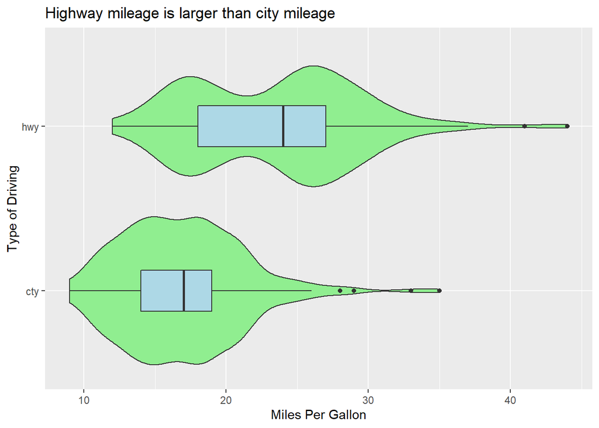

```r
mpg %>%
  select(cty, hwy) %>%
  gather(cty, hwy, key = type_of_driving, value = mileage) %>%
  ggplot(aes(x = type_of_driving, y = mileage)) +
  geom_violin(fill = "lightgreen") +
  geom_boxplot(width = 0.25, fill = "lightblue") +
  labs(title = "Highway mileage is larger than city mileage",
       x = "Type of Driving",
       y = "Miles Per Gallon") +
  coord_flip()
```